# JIBE_AirPollution_Validation_Melb

Qin, Harry, Steve

2025-07-24

# Prepare monitoring and related data

## Import data

```r
# monitoring sites with hourly data, from EPA (note: 'NO2' and 'BPM2.5'
# are hourly; there is also 'PPM2.5' for some sites which is 24 hr average)
melb_hourly <- read_xlsx("../data/original/2018_All_sites_air_quality_hourly_avg_AIR-I-F-V-VH-O-S1-DB-M2-4-0.xlsx")

# monitoring sites with annual data only (includes both EPA and others)
melb_annual_NO2 <- read_xlsx("../data/processed/annual_pm_no2_vic.xlsx",
                             sheet = "no2_vic_2017-2019")

melb_annual_PM2.5 <- read_xlsx("../data/processed/annual_pm_no2_vic.xlsx",
                               sheet = "pm25_vic_2017-2020")

# classified sites
sites_classified <- read.csv("../data/processed/monitoring site locations classified.csv")
```

The EPA data provides hourly NO2 data, and hourly PM2.5 data (‘BPM2.5’) as well as daily PM2.5 data (‘PPM2.5’) for some of the same sites.

The annual data was compiled by Luke Knibbs, and includes both EPA sites and other sites. Among the other sites, six (Barbara Beyer Reserve, Donald Mclean Reserve, Miller Street, Primula Ave, Railway Reserve and Yarraville) are in the vicinity of the West Gate Freeway, monitored as part of the West Gate Tunnel Project: https://bigbuild.vic.gov.au/library/west-gate-tunnel-project/air-quality-monitoring-reports.

Sites have been classified as ‘Urban’, ‘Suburban’ and ‘Rural’, and as ‘Background’, ‘Traffic’ and ‘Industrial’, based on the criteria specified in https://uk-air.defra.gov.uk/networks/site-types. There are no ‘Rural’ sites. There are also no ‘Traffic’ sites. ‘Traffic’ classification requires a sample probe no more than 10m from the kerbside. There are no such sites in the sample (though there are a number of sites where the distance from the kerbside is between 10m and 15m: Alphington, Brooklyn, Campbellfield, Melbourne CBD, Millers Rd and Yarraville; and also Churchill (though in that case the road is a residential loop road with minimal traffic).

### NO2 monitoring sites in Greater Melbourne

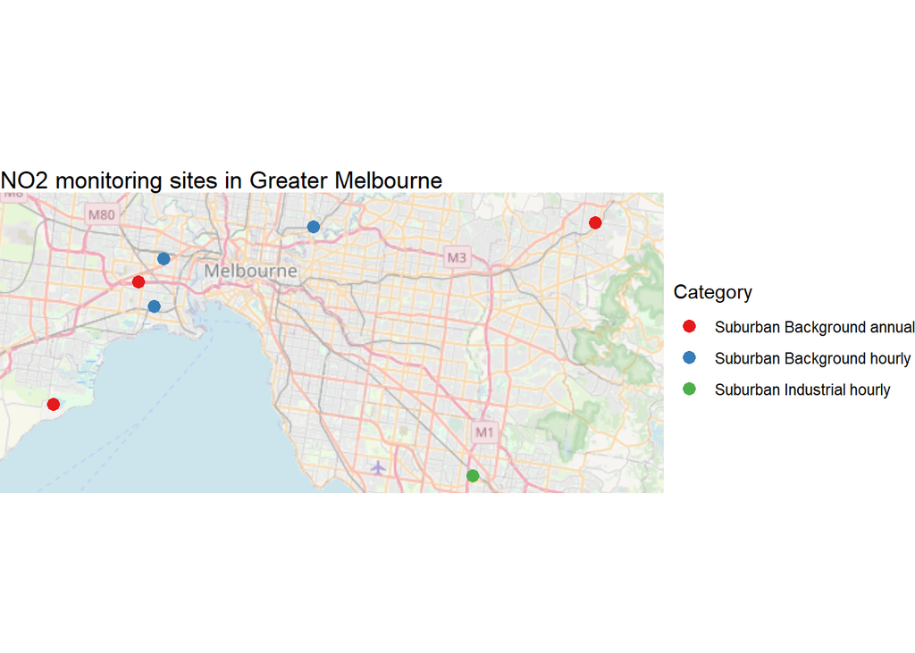

```r
# bounding box for map (for both NO2 and PM2.5 maps)
bbox <- st_sfc(st_polygon(list(matrix(c(
  144.7, -38.0,  # Bottom-left (lon, lat)
  145.4, -38.0,  # Bottom-right
  145.4, -37.75, # Top-right
  144.7, -37.75, # Top-left
  144.7, -38.0   # Closing the polygon
), ncol = 2, byrow = TRUE))), crs = 4326)

# transform to EPSG:3857
bbox_3857 <- st_transform(bbox, 3857)

# extract limits
xlim <- st_bbox(bbox_3857)[c("xmin", "xmax")]
ylim <- st_bbox(bbox_3857)[c("ymin", "ymax")]

# function to create map (for both NO2 and PM2.5)
site_plot <- function(mydata, mytitle) {
  ggplot(mydata) +
  annotation_map_tile(type="osm", zoom=10, alpha=0.6, progress = "none") +
  geom_sf(aes(colour = category), size = 3) +
  scale_color_brewer(palette = "Set1") +
  labs(title = mytitle, color = "Category") +
  coord_sf(xlim = xlim, ylim = ylim, expand = FALSE) +
    theme_void()  # remove labels, ticks, grids
}

# categorise NO2 sites by frequency of observations
hourly_sites_NO2 <- melb_hourly %>%
  filter(param_short_name == "NO2") %>%
  .$sp_name %>% unique() %>% gsub(" ", "_", .)
annual_sites_NO2 <- melb_annual_NO2 %>%
  filter(year_ == 2018) %>%
  .$site %>% unique()
NO2_data <- sites_classified %>%
  filter(region == "Greater Melbourne") %>%
  mutate(freq = case_when(
    site %in% hourly_sites_NO2 ~ "hourly",
    site %in% annual_sites_NO2 ~ "annual"
  )) %>%
  filter(!is.na(freq)) %>%  # omit where no NO2 data (ie no 'freq' field)
  mutate(category = paste(class, freq)) %>%
  dplyr::select(site, long, lat, category) %>%
  st_as_sf(coords = c("long", "lat"), crs = 4326) %>%
  st_transform(3857)

# plot map
site_plot(NO2_data, "NO2 monitoring sites in Greater Melbourne")
```

### PM2.5 monitoring sites in Greater Melbourne

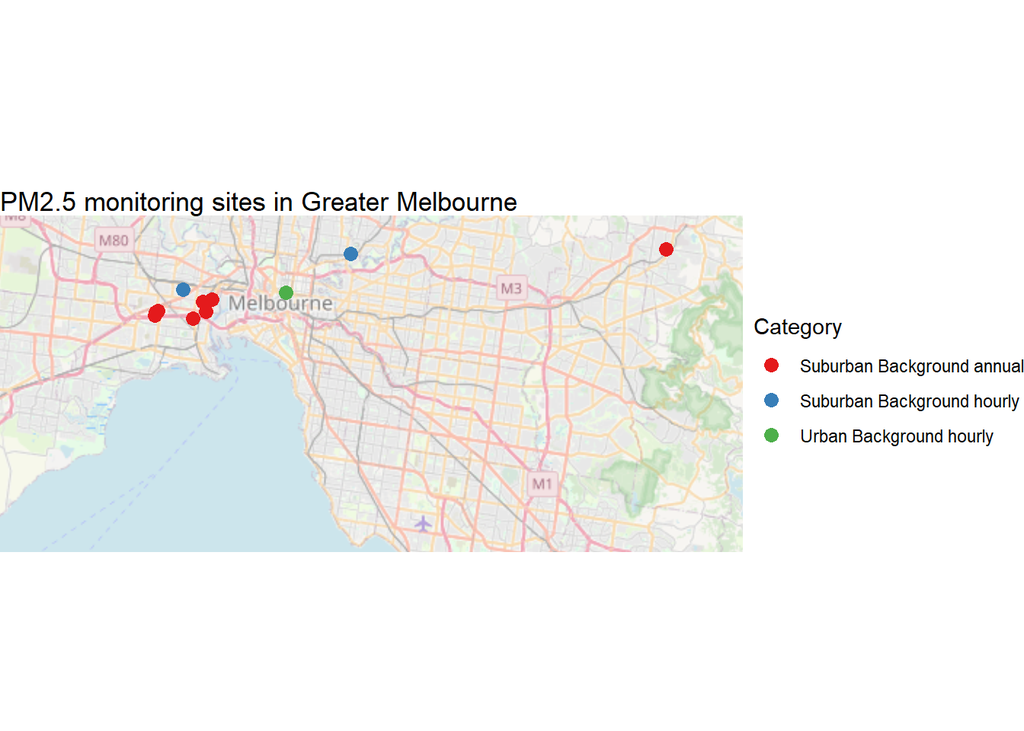

```r
# categorise PM2.5 sites by frequency of observations
hourly_sites_PM2.5 <- melb_hourly %>%
  filter(param_id == "BPM2.5") %>%
  .$sp_name %>% unique() %>% gsub(" ", "_", .)
daily_sites_PM2.5 <- melb_hourly %>%
  filter(param_id == "PPM2.5")  %>%
  .$sp_name %>% unique() %>% gsub(" ", "_", .)
annual_sites_PM2.5 <- melb_annual_PM2.5 %>%
  filter(year_ == 2018) %>%
  .$site %>% unique()
PM2.5_data <- sites_classified %>%
  filter(region == "Greater Melbourne") %>%
  mutate(freq = case_when(
    site %in% hourly_sites_PM2.5 ~ "hourly",
    site %in% daily_sites_PM2.5 ~ "daily",
    site %in% annual_sites_PM2.5 ~ "annual"
  )) %>%
  filter(!is.na(freq)) %>%  # omit where no PM2.5 data (ie no 'freq' field)
  mutate(category = paste(class, freq)) %>%
  dplyr::select(site, long, lat, category) %>%
  st_as_sf(coords = c("long", "lat"), crs = 4326) %>%
  st_transform(3857)

# plot map
site_plot(PM2.5_data, "PM2.5 monitoring sites in Greater Melbourne")
```

## Review hourly against annual data

Where we have both hourly values and annual values, it’s assumed that the annual values would be the mean of the hourly values. This is generally the case. Specifically: - some NO2 figures match exactly, while some have the annual value rounded to the nearest number, which matches the rounded mean value. - PM2.5 figures are rounded to one decimal place, which sometimes matches the rounded mean value, but in other cases differs by 0.1 or 0.2 from the rounded mean value.

Note that we do not have daily PM2.5 values for any of the sites for which we have annual PM2.5 values (and so daily values are not included in the table below).

```r
annual <- bind_rows(
  melb_annual_NO2 %>%
    filter(year_ == 2018) %>%
    mutate(param_id = "NO2") %>%
    mutate(site = gsub("_", " ", site)) %>%
    dplyr::select(site, param_id, annual_value = NO2_annual_ppb),
  melb_annual_PM2.5 %>%
    filter(year_ == 2018) %>%
    mutate(param_id = "PM2.5") %>%
    mutate(site = gsub("_", " ", site)) %>%
    dplyr::select(site, param_id, annual_value = `PM25_annual_µg/m^3`)
) %>%
  filter(!is.na(annual_value))

melb_hourly_annualised <- melb_hourly %>%

  # filter to relevant pollutants
  filter(param_id %in% c("NO2", "BPM2.5", "PPM2.5")) %>%
  mutate(basis = ifelse(param_id %in% c("NO2", "BPM2.5"), "hourly", "daily")) %>%
  mutate(param_id = ifelse(param_id %in% c("BPM2.5", "PPM2.5"), "PM2.5", param_id)) %>%

  # calculate mean of the hourly/daily values
  # mutate(sp_name = gsub(" ", "_", sp_name)) %>%
  rename(site = sp_name) %>%
  group_by(site, param_id, basis) %>%
  summarise(mean_value = mean(value)) %>%
  ungroup()

annual_compared <- melb_hourly_annualised %>%

  # join the annual values
  left_join(annual, by = c("site", "param_id")) %>%
  filter(!is.na(annual_value)) %>%
  arrange(param_id, site)

knitr::kable(annual_compared, col.names = c("Site", "Parameter", "Measuring basis",
                                            "Mean value", "Annual value"))
```

| Site | Parameter | Measuring basis | Mean value | Annual value |
| --- | --- | --- | --- | --- |
| Alphington | NO2 | hourly | 9.558120 | 9.558120 |
| Altona North | NO2 | hourly | 9.467912 | 9.467912 |
| Dandenong | NO2 | hourly | 9.800705 | 9.800705 |
| Footscray | NO2 | hourly | 10.274531 | 10.000000 |
| Geelong South | NO2 | hourly | 5.681722 | 5.681722 |
| Morwell South | NO2 | hourly | 5.124430 | 5.000000 |
| Traralgon | NO2 | hourly | 5.776333 | 6.000000 |
| Geelong South | PM2.5 | hourly | 6.502762 | 6.500000 |
| Melbourne CBD | PM2.5 | hourly | 8.072998 | 7.900000 |
| Moe | PM2.5 | hourly | 6.427079 | 6.400000 |
| Morwell East | PM2.5 | hourly | 6.784596 | 6.700000 |
| Morwell South | PM2.5 | hourly | 6.512849 | 6.500000 |
| Traralgon | PM2.5 | hourly | 8.024734 | 7.800000 |

## Compare all annual/annualised results by class

Review the annualised results for all sites for which either hourly or annual results exist (whether inside Greater Melbourne or not), to explore differences between classifications. Note that the plots below include all sites for which we have any NO2 or PM2.5 readings, even those for which we don’t have hourly readings.

```r
# join annual and annualised hourly results
all_annual <- melb_hourly_annualised %>%

  # remove annualised daily values, as we have annualised hourly values for same sites
  filter(basis == "hourly") %>%
  dplyr::select(-basis) %>%
  rename(value = mean_value) %>%

  #  add the annual values, but only where sites don't have annualised hourly values
  bind_rows(annual %>%
              filter(!site %in% melb_hourly_annualised$site) %>%
              rename(value = annual_value)) %>%

  # join classifications
  left_join(sites_classified %>%
              mutate(site = gsub("_", " ", site)) %>%
              dplyr::select(site, class),
            by = "site")

# function for plot of readings
annual_plot <- function(mydata, mytitle, my_x) {
  ggplot(mydata) +
    geom_col(aes(x = value, y = fct_rev(site), fill = class)) +
    scale_fill_brewer(palette = "Set1") +
    labs(title = mytitle,
         x = my_x,
         y = "Site",
         fill = "Classification") +
    theme_minimal()
}


melb_NO2 <- all_annual %>% filter(param_id == "NO2")
melb_PM2.5 <- all_annual %>% filter(param_id == "PM2.5")
```

Plot the NO2 readings. Among the Melbourne readings, there is little difference based on classification, except for Primula Ave, which is one of the West Gate Fwy sites monitored as part of the West Gate Tunnel project. Alphington (where the measuring station is between 10m and 15m from the road, and so is close to a ‘Traffic’ classification) is no higher than the ‘Background’ sites. Readings for the sites outside Greater Melbourne are lower, even though both the Background sites (Morwell South and Traralgon) are in the Latrobe Valley.

The lowest Background site is Morwell South.

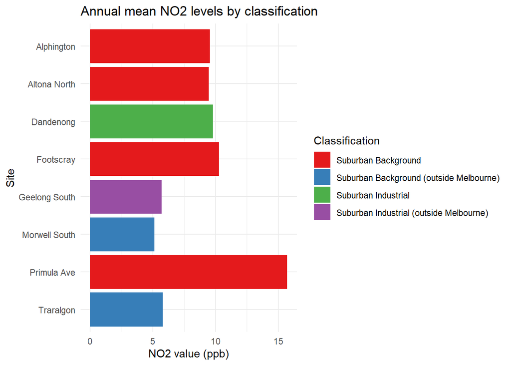

```r
annual_plot(melb_NO2, "Annual mean NO2 levels by classification", "NO2 value (ppb)")
```

Plot the PM2.5 readings. Again, among the Melbourne sites there is little difference based on classification. Alphington and Yarraville (where the measuring stations are between 10m and 15m from the road, and so are close to a ‘Traffic’ classification) are not notably higher than the ‘Background’ sites. The readings for sites outside Greater Melbourne are generally slightly (but not much) lower than those in Greater Melbourne, again noting that all the Background sites (Churchill, Moe, Morwell East, Morwell South and Traralgon) are in the Latrobe Valley.

The lowest Background site is Churchill.

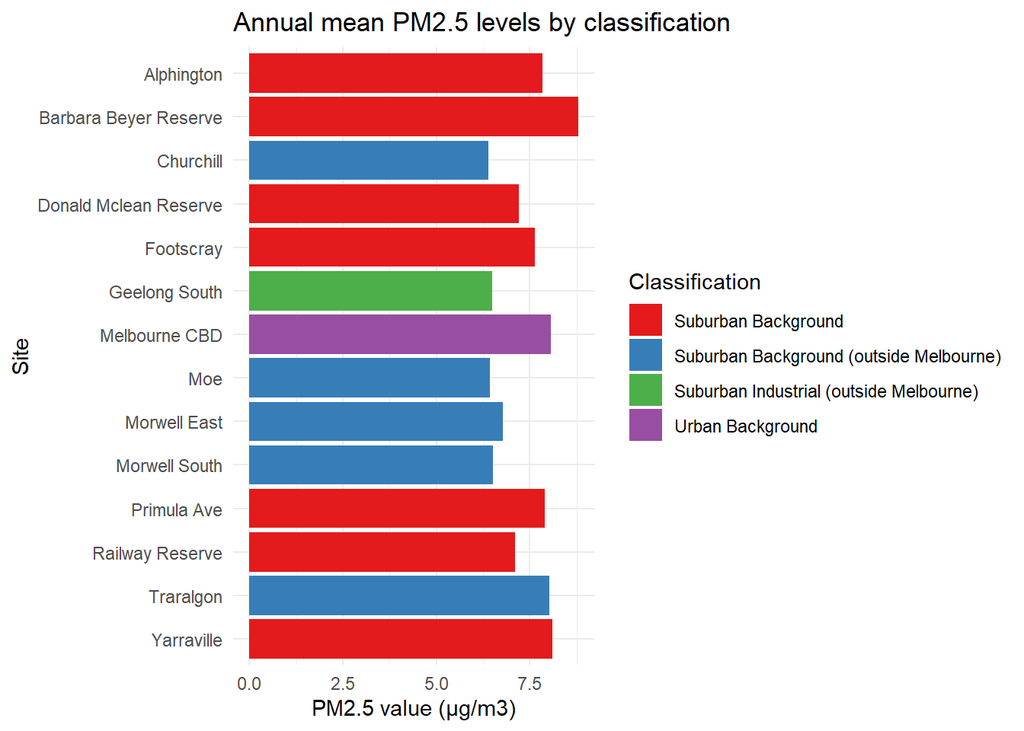

```r
annual_plot(melb_PM2.5, "Annual mean PM2.5 levels by classification", "PM2.5 value (μg/m3)")
```

# Calculate increment of the valid sites

## Reference sites

In the Manchester validation code, only Urban Traffic sites are selected for validation, and they are compared to reference Urban and Rural Background sites.

A different approach is required for Melbourne, where there are no true Traffic sites, and nearly all sites are Background. Accordingly: - the Industrial sites are excluded, - the Background sites in Greater Melbourne are used for validation, and - the Background sites outside Greater Melbourne with the lowest readings (Morwell South for NO2 and Churchill for PM2.5) are used as reference sites.

Morwell South and Churchill are perhaps not ideal as reference sites, as they are located in the Latrobe Valley where the State’s coal-fired power stations are situated, but are the best available as (1) they are the sites with the lowest readings, and (2) all the other non-Melbourne Background sites for which we have 2018 NO2 or PM2.5 data are also in the Latrobe Valley.

```r
# Reference sites
ref_NO2 <- "Morwell South"
ref_PM2.5 <- "Churchill"
```

Rates for the reference sites - that is, background NO2 and PM2.5 rates to be used in the model - are as follows. These results are stated in μg/m3. (The values of NO2 for the Melbourne monitoring sites provided by the EPA are in ppb (parts per billion). Based on the Manchester validation script, it’s assumed the Matsim outputs are in μg/m3 (micrograms per cubic meter). Accordingly, the EPA values are converted to μg/m3 by multiplying by 1.88 (see https://uk-air.defra.gov.uk/reports/cat06/0502160851_Conversion_Factors_Between_ppb_and.pdf, using the WHO value (25°C) rather than the EC value (20°C)).)

```r
# Table of background rates from reference sites
NO2_ref_value <- round(all_annual %>%
  filter(site == ref_NO2 & param_id == "NO2") %>%
  pull(value) * 1.88,  # multiplying by 1.88 to convert ppb to μg/m3
  1)  # rounded to 1 decimal place

PM2.5_ref_value <- round(all_annual %>%
  filter(site == ref_PM2.5 & param_id == "PM2.5") %>%
  pull(value),
  1)  # rounded to 1 decimal place

ref_value_table = rbind(
  c("NO2", ref_NO2, NO2_ref_value),
  c("PM2.5", ref_PM2.5, PM2.5_ref_value)
)

knitr::kable(ref_value_table, col.names = c("Pollutant", "Site", "Background rate (μg/m3)"))
```

| Pollutant | Site | Background rate (μg/m3) |
| --- | --- | --- |
| NO2 | Morwell South | 9.6 |
| PM2.5 | Churchill | 6.4 |

The model also requires ‘incremental’ values, which in Manchester are calculated as the value for a reference traffic site, minus the value for the reference background site, for each pollutant. As noted above, Melbourne has no ‘traffic’ sites meeting the criterion of a sensor within 10m of the road. Accordingly, for Melbourne, the incremental values are calculated as the mean of the suburban & urban background values, minus the value for the reference background site, for each pollutant.

```r
# Table of incremental rates (suburban/urban background minus reference)
NO2_inc_value <- round(mean(all_annual %>%
                         filter(param_id == "NO2" &
                                  class %in% c("Suburban Background", "Urban Background")) %>%
                           pull(value)) * 1.88 - NO2_ref_value, 1)  # multiplying by 1.88 to convert ppb to μg/m3

PM2.5_inc_value <- round(mean(all_annual %>%
                                filter(param_id == "PM2.5" &
                                         class %in% c("Suburban Background", "Urban Background")) %>%
                                pull(value)) - PM2.5_ref_value, 1)

inc_value_table = rbind(
  c("NO2", NO2_inc_value),
  c("PM2.5", PM2.5_inc_value)
)

knitr::kable(inc_value_table, col.names = c("Pollutant", "Incremental rate (μg/m3)"))
```

| Pollutant | Incremental rate (μg/m3) |
| --- | --- |
| NO2 | 11.6 |
| PM2.5 | 1.4 |

## Prepare relevant hourly Melbourne and reference site data

```r
# filter Melb and ref site hourly data to relevant NO2 & PM2.5 readings, plus other required details
melbourne <- melb_hourly %>%

  # filter to relevant pollutants, and create separate columns for each
  # (note that param_short_name 'PM2.5' is only the hourly readings, not the
  # daily readings that also exist for some of the same sites)
  filter(param_short_name %in% c("NO2", "PM2.5")) %>%
  mutate(param_short_name = tolower(param_short_name)) %>%
  pivot_wider(names_from = param_short_name, values_from = value) %>%

  # restructure other columns as required
  mutate(source = "epa") %>%
  mutate(code = as.character(sample_point_id)) %>%

  # select required columns
  dplyr::select(source, date = sample_datetime, site = sp_name, code, no2, pm2.5,
                latitude, longitude) %>%

  # join the classifications
  left_join(sites_classified %>%
              mutate(site = gsub("_", " ", site)) %>%
              dplyr::select(site, region, site_type = class),
            by = "site") %>%

  # filter to Greater Melbourne and reference sites
  filter(region == "Greater Melbourne" |
           (site == ref_NO2 & !is.na(no2)) |
           (site == ref_PM2.5 & !is.na(pm2.5))) %>%
  dplyr::select(-region)
```

Check the structure of the Melbourne data

```r
knitr::kable(head(melbourne))
```

| source | date | site | code | no2 | pm2.5 | latitude | longitude | site_type |
| --- | --- | --- | --- | --- | --- | --- | --- | --- |
| epa | 2018-01-01 | Alphington | 10001 | NA | 3.7 | -37.77841 | 145.0306 | Suburban Background |
| epa | 2018-01-01 | Alphington | 10001 | 3 | NA | -37.77841 | 145.0306 | Suburban Background |
| epa | 2018-01-01 | Churchill | 10219 | NA | 5.3 | -38.30431 | 146.4149 | Suburban Background (outside Melbourne) |
| epa | 2018-01-01 | Footscray | 10003 | NA | 6.6 | -37.80488 | 144.8728 | Suburban Background |
| epa | 2018-01-01 | Footscray | 10003 | 6 | NA | -37.80488 | 144.8728 | Suburban Background |
| epa | 2018-01-01 | Melbourne CBD | 10239 | NA | 1.2 | -37.80740 | 144.9700 | Urban Background |

Sites for validation: in total, 4 Urban or Suburban Background sites, plus the two reference sites (one for each pollutant)

```r
sites <- melbourne %>%
  select(source, site, code, site_type) %>%
  distinct() %>%
  filter(site_type %in% c("Urban Background", "Suburban Background") | site %in% c(ref_NO2, ref_PM2.5)) %>%
  mutate(site_type = factor(site_type, levels = c("Suburban Background", "Urban Background",
                                                  "Suburban Background (outside Melbourne)"))) %>%
  arrange(site_type, site)

knitr::kable(sites)
```

| source | site | code | site_type |
| --- | --- | --- | --- |
| epa | Alphington | 10001 | Suburban Background |
| epa | Altona North | 10006 | Suburban Background |
| epa | Footscray | 10003 | Suburban Background |
| epa | Melbourne CBD | 10239 | Urban Background |
| epa | Churchill | 10219 | Suburban Background (outside Melbourne) |
| epa | Morwell South | 10217 | Suburban Background (outside Melbourne) |

## Plots of hourly Melbourne and reference data

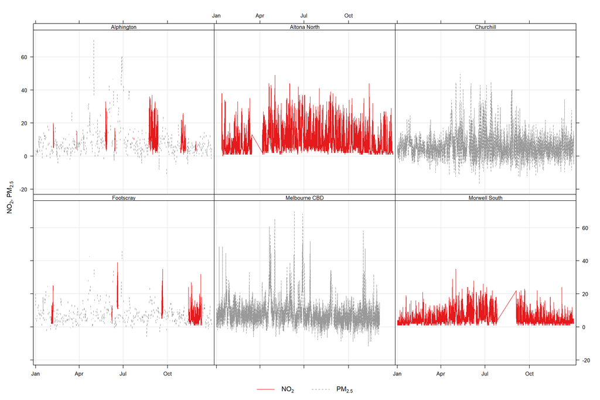

```r
timePlot(melbourne %>% filter(site %in% sites$site), type = "site", pollutant = c("no2", "pm2.5"))
```

```r
melbourne_time = timeVariation(melbourne %>% filter(site %in% sites$site), type = "site", pollutant = c("no2", "pm2.5"))
```

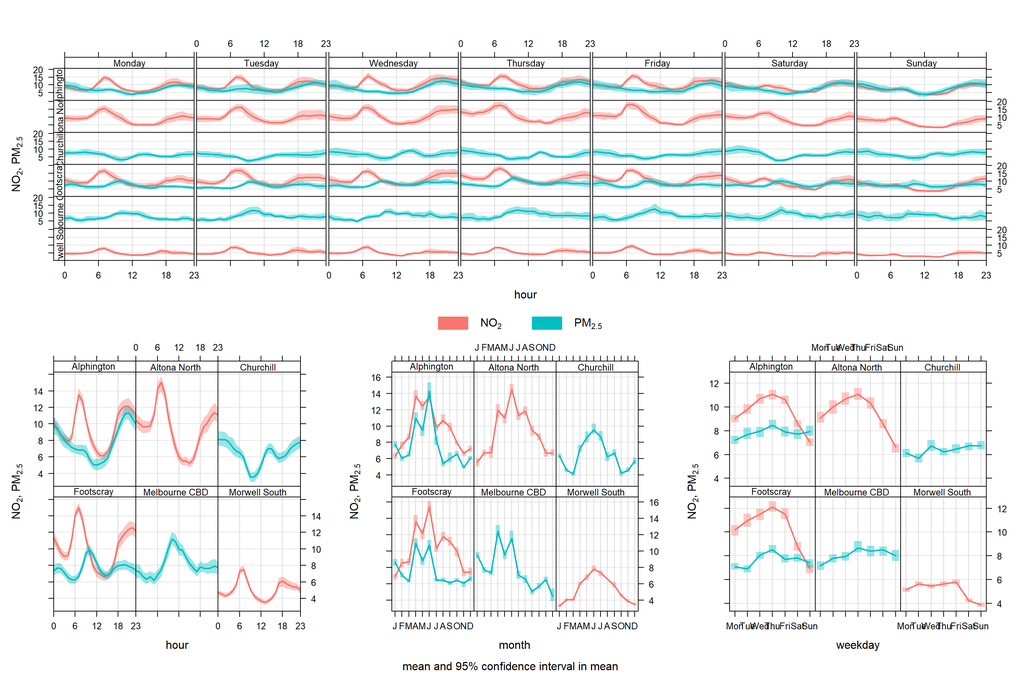

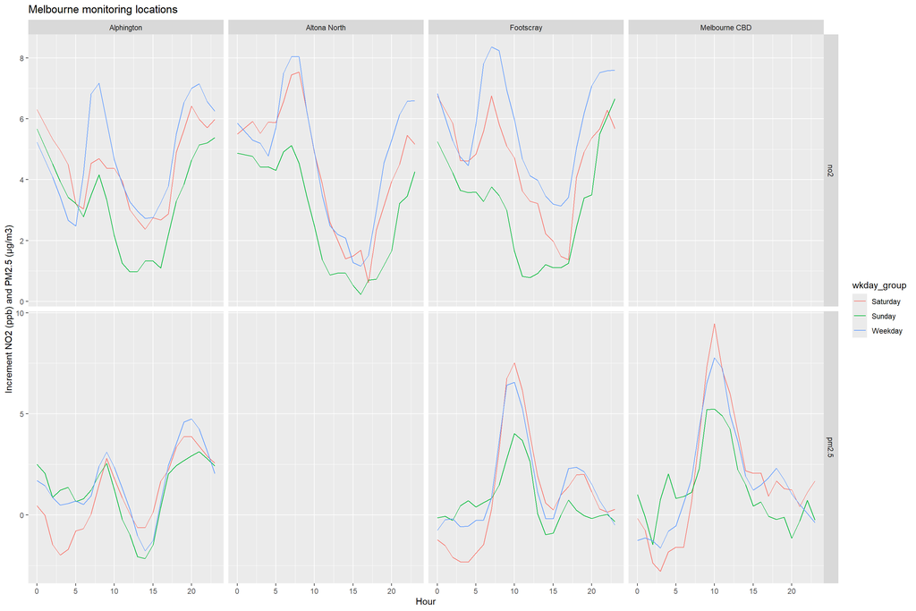

```r
melbourne_dayHour <- melbourne_time$data$day.hour %>%
  mutate(wkday_group = case_when(wkday %in% c("Monday", "Tuesday", "Wednesday",
                                              "Thursday", "Friday") ~ "Weekday" ,
                                 TRUE ~ wkday))%>%
  group_by(variable, site, wkday_group, hour) %>%
  summarise(mean_value = mean(Mean, na.rm = FALSE))%>%
  ungroup() %>%
  spread(site, mean_value) %>%
  rename(mean_value_ref_no2 = `Morwell South`, mean_value_ref_pm2.5 = `Churchill`) %>%
  gather(site, mean_value, -c(variable, wkday_group, hour,
                              mean_value_ref_no2, mean_value_ref_pm2.5)) %>%
  # calculate increment as site value minus reference value
  mutate(mean_value_increment = case_when(
    variable == "no2" ~ mean_value - mean_value_ref_no2,
    variable == "pm2.5" ~ mean_value - mean_value_ref_pm2.5
  ))

ggplot(melbourne_dayHour,
       aes(x = hour,
           y = mean_value_increment, group = wkday_group, colour = wkday_group)) +
  geom_line() +
  facet_grid(variable ~ site, scales = "free_y") +
  labs(title = "Melbourne monitoring locations",
       x = "Hour",
       y = "Increment NO2 (ppb) and PM2.5 (μg/m3)")
```